# ridgeline density plots

David McGaughey

# Intro

Here we’ll be making the hottest visualization of 2017 - the *joy plot* or *ridgeline plot*.

Ridgelines are partially overlapping density line plots. They are useful for densely showing changes in many distributions over time / condition / etc.

This type of visualization was inspired by the [cover art](https://en.wikipedia.org/wiki/Unknown_Pleasures) from Joy Division’s album Unknown Pleasures and implemented in the R package ggridges by Claus Wilke.

While the original term for this plot took off as *joy plot* it has since been changed to a *ridgeline plot* or *ridges plots*, as discussed at length [here](http://serialmentor.com/blog/2017/9/15/goodbye-joyplots).

Anyways, Claus has a *beautiful* intro to his package [here](https://cran.r-project.org/web/packages/ggridges/vignettes/gallery.html). I will not reproduce any of his plots, as I want you to click the link. Plus they are way cooler looking than what we will be making. Which is real(ish) data from people in my division.

# Load Davide merged data

This is a highly cut down version of his original data - which is a 160mb csv file. The csv for this exercise can be found [here](https://github.com/davemcg/Let_us_plot/blob/master/005_ggridges/davide_cell_size_data.csv).

It contains cell area size for thousands of cells which have had a drug perturbation, split by wells in a dish. One drug per well.

```r
library(tidyverse)
library(ggridges)
merged.df <- read_csv('~/git/Let_us_plot/005_ggridges/davide_cell_size_data.csv')
```

# What does the data look like?

```r
head(merged.df)
```

```
## # A tibble: 6 × 3
##   Well.names  Area Drug
##   <chr>      <dbl> <chr>
## 1 D07          643 20(S
## 2 D07          388 20(S
## 3 D09          290 20(S
## 4 D08         1174 20(S
## 5 D09          186 20(S
## 6 D09         7062 20(S
```

# First we create a fake DMSO to match each drug so we can see the ‘null’ distribution matched with each drug in the visualization below

I know `for` loops are out of trend, but I find them easier to write *and* read compared to `purrr`. A lot less compact, I concede.

This is a bit hacky, but I want to duplicate the DMSO data and assign it to each drug. Later we’ll be splitting the plot by drug, so we can see both the drug data *and* the DMSO data in the section.

```r
# for background DMSO plot
fake_DMSO_drug <- data.frame()
for (i in (merged.df$Drug %>% unique())){
  print(i)
  fake_DMSO_drug <- rbind(fake_DMSO_drug, merged.df %>% filter(Drug=='DMSO') %>% mutate(Drug = i, Well.names=paste0('0DMSO_', i), DMSO='Yes'))
}
```

```
## [1] "20(S"
## [1] "3-Am"
## [1] "Brom"
## [1] "Cili"
## [1] "Ctrl"
## [1] "DMSO"
## [1] "ETP"
## [1] "G-Pr"
## [1] "GANT"
## [1] "HA 1"
## [1] "IMR-"
## [1] "IWP-"
## [1] "IWR-"
## [1] "LGK-"
## [1] "LY41"
## [1] "Metf"
## [1] "PJ 3"
## [1] "SANT"
## [1] "Sodi"
## [1] "Tori"
## [1] "UNC"
## [1] "Valp"
## [1] "Wnt-"
## [1] "WYE"
```

```r
# order drugs by median area
drug_order <- merged.df %>% group_by(Drug) %>% summarise(MedianArea=median(Area)) %>% arrange(MedianArea) %>% pull(Drug)
```

# ridgeline plot, showing each well separately

Several wells got the same drugs. So there are multiple plots per drug.

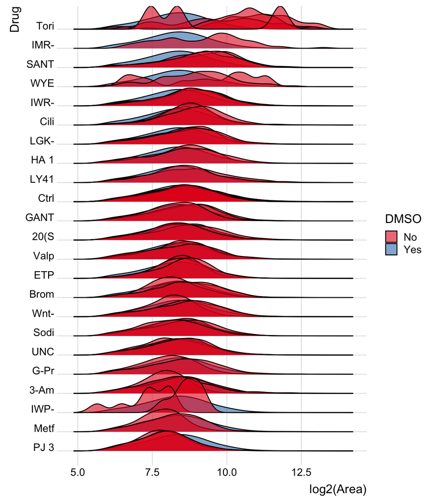

```r
bind_rows(merged.df %>% mutate(DMSO='No'),fake_DMSO_drug) %>%
  filter(Drug!='DMSO', Drug!='Pyr') %>% # don't need DMSO plot now and Pyr is empty
  mutate(Drug=factor(Drug, levels=drug_order)) %>% # reorder drugs by drug_order above
  ggplot(aes(y = Drug, x=log2(Area), group=Well.names, fill=DMSO)) +
  geom_density_ridges(alpha=0.6) +
  theme_ridges() +
  scale_fill_brewer(palette = 'Set1')
```

# Same, but merging all wells together

Now merge all the wells together. Notice how the group is now `Well.names2`

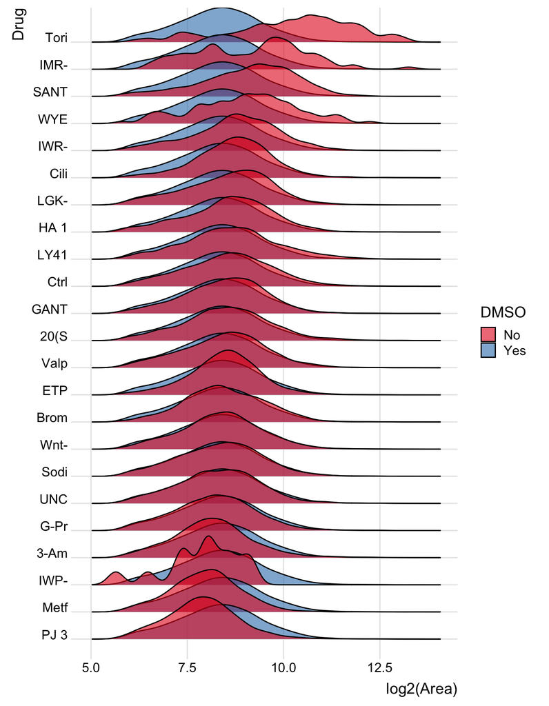

```r
bind_rows(merged.df %>%
            mutate(DMSO='No', Well.names2=paste0('Orig', Drug)),
          fake_DMSO_drug %>%
            mutate(Well.names2 = Well.names)) %>%
  filter(Drug!='DMSO', Drug!='Pyro') %>% # dont' need DMSO plot now and Pyroxamine is empty
  mutate(Drug=factor(Drug, levels=drug_order)) %>% # reorder drugs by drug_order above
  ggplot(aes(y = Drug, x = log2(Area), group=Well.names2, fill=DMSO)) +
  geom_density_ridges(alpha=0.6) +
  theme_ridges() +
  scale_fill_brewer(palette = 'Set1')
```

# There’s a large variation in the number of counts

How did I know? Because a bunch of the density plots were super wavy - which means (almost always) that the number of counts in that sample is very low. Low numbers = high variance.

So IMR, IMP, Tori, and WYE are *problem* tests. Perhaps they are just killing the cells? Something for Davide to examine.

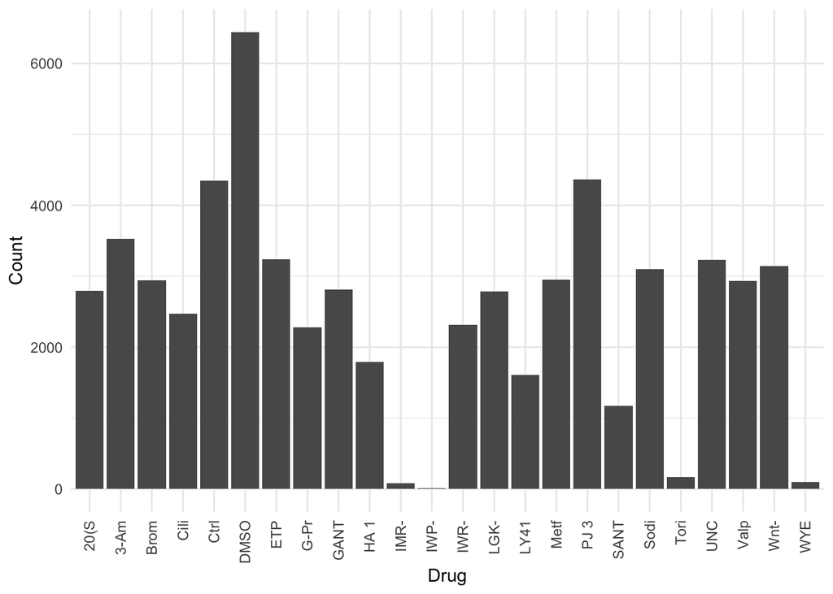

```r
cell_area_counts_by_drug <- merged.df %>%
  group_by(Drug) %>%
  summarise(Count=n())

cell_area_counts_by_drug  %>%
  ggplot(aes(x=Drug, y=Count)) +
  geom_bar(stat='identity') +
  theme_minimal() +
  theme(axis.text.x = element_text(angle = 90, vjust = 0.5, hjust=1))
```